# Statistical Learning - Lab 2

Bar Weinstein and Hananel Giat

May 14, 2019

# Question 1

## K-means algorithm

We build a `K-Means` function using *K-Mean ++* method for computing first iteration means. To use the function the user has to select the $K$ number of clustering of choice.

```r
k_means = function(X,K,means=FALSE,n_iter = 100L){
    n = nrow(X)
    p = ncol(X)
# initialize k-mean selection function using 'k-means ++' algo; return vector of mean with length k
  initialize = function(X,K){
    X = as.matrix(X)
    center = matrix(c(X[sample(seq(1,n),1),]), ncol = p, nrow = 1) # random uniformly select one row as first center
    for (j in seq(2,K)){
      dist = matrix(apply(X,1,function(y){apply(center, 1, function(x){sum((x-y)^2)})}),nrow = n, ncol = nrow(center))
      dist = apply(dist, 1, min)
      probs = dist / sum(dist)
      cum_prob = cumsum(probs)
      idx = runif(n = 1,0,1)
      c = 0
      for (i in (seq(length(cum_prob)))){
        if(idx < cum_prob[i]){
          c = i
          break
        }
      }
      center = rbind(center,c(X[c,]))
    }
    return(center)
  }
  if(!means){ # if not given 'means' then use K-means ++ to chose initial K centeroids
      means = initialize(X,K)}
  X = as_tibble(X)
  m_dist = matrix(apply(X,1,function(y){apply(means, 1, function(x){sum((x-y)^2)})}),nrow = n, ncol = nrow(means), byrow = T)
  ct_idx = apply(m_dist, 1, which.min)
  X = as_tibble(cbind(X,ct_idx)) # last col is for the cluster group 'Ct = {1,...,K}'
  names(X)[p+1] = "ct_idx"
  for (iter in seq(1,n_iter)){
    old_ct = ct_idx # Cluster from previous iter is now old_ct
    means = X %>% group_by(ct_idx)  %>% summarize_all(mean, na.rm = T) %>% dplyr::select(-ct_idx)
    m_dist = matrix(apply(X[,-c(p+1)],1,function(y){apply(means, 1, function(x){sum((x-y)^2)})}),nrow = n, ncol = nrow(means), byrow = T)
    ct_idx = apply(m_dist, 1, which.min) # new clustering
    X[,p+1] = ct_idx
    if(all(old_ct == ct_idx)){ # convergence of clustering!
      break
    }
  }
  return(list("clusters" = ct_idx, "centers" = means, "iter" = iter))
}
```

## The Data

1. We built a function `mix_gaussian_df` that generate a new data set of mixed gaussian given the user selection of 3 mean vectors and variance
2. We generate $3 \times 4 \times 50$ data bases with three different variances ($\sigma \in \{1,10,100\}$) and 4 different dimension ($P \in \{10,20,50,80\}$), and $50$ from each one of the combination.
3. In addition to the above data-bases, we computed the first 5 principal componets - another $3 \times 4 \times 50$ data bases
4. We compared the accuarcy of the `K-Means` algo to the real partition (and we know it becuase we generated the data!) using the formula
   $$acc(C_i) = \frac{max(|w_j|)}{|C_i|}$$
   while $C_i =$ the “real” mixed gaussian rows, i.e. $C_1 = Rows(1:20)$, $|w_j|$ is the size of cluster $j$ in the subset $C_i$ and $|C_i|$ is the total observation, i.e. $C_1 = 20$

And the total accuracy of `K-Means` run on a specific data-frame is defined as
$$Acc(DF_i-Cluster) = \frac{1}{3}\sum_{i=1}^{3}acc(C_i)$$

And for each $P \in \{10,20,50,80\}$ , $\sigma_\epsilon^2 \in \{1,10,100\}$, and $Algo = \{None,PCA\}$ we compute the Avg and Std-Error Accuracy.

Notice that we didn’t use a traditional accuracy score becuase most of them assume the user *don’t* know the real cluster, but we know the real one hence we used a measure that check if cluster’s fit is accurate compared to the real one, i.e. if $w_j$ is a cluster that fit the real one perfectly than $acc(C_i) = 1$.

```r
mix_gaussian_df = function(mu1,mu2,mu3,sigma,p){
    n1 = length(mu1); n2 = length(mu2); n3 = length(mu3)
    df = matrix(nrow = n1+n2+n3, ncol = p)
    df[1:n1,] = t(mvrnorm(n = p, mu = mu1, Sigma = diag(sigma,nrow = n1, ncol = n1)))
    df[n1+1:n2,] = t(mvrnorm(n = p, mu = mu2, Sigma = diag(sigma,nrow = n2, ncol = n2)))
    df[n2+n1+1:n3,] = t(mvrnorm(n = p, mu = mu3, Sigma = diag(sigma,nrow = n3, ncol = n3)))
    return(df)
}
```

Accuracy Comprasion

| (P,Sigma,Algo) | Avg | Std-Err |
| --- | --- | --- |
| 10,1,None | 0.6117 | 0.1007 |
| 10,1,PCA | 0.4726 | 0.0590 |
| 10,10,None | 0.4556 | 0.0556 |
| 10,10,PCA | 0.4439 | 0.0403 |
| 10,100,None | 0.4534 | 0.0425 |
| 10,100,PCA | 0.4596 | 0.0533 |
| 20,1,None | 0.7124 | 0.1104 |
| 20,1,PCA | 0.4838 | 0.0560 |
| 20,10,None | 0.4953 | 0.0659 |
| 20,10,PCA | 0.4510 | 0.0473 |
| 20,100,None | 0.4780 | 0.0536 |
| 20,100,PCA | 0.4506 | 0.0467 |
| 50,1,None | 0.7765 | 0.0821 |
| 50,1,PCA | 0.4643 | 0.0511 |
| 50,10,None | 0.5426 | 0.0894 |
| 50,10,PCA | 0.4612 | 0.0566 |
| 50,100,None | 0.5271 | 0.1004 |
| 50,100,PCA | 0.4633 | 0.0571 |
| 80,1,None | 0.7844 | 0.0582 |
| 80,1,PCA | 0.4962 | 0.0798 |
| 80,10,None | 0.5740 | 0.1247 |
| 80,10,PCA | 0.4564 | 0.0724 |
| 80,100,None | 0.5560 | 0.1047 |
| 80,100,PCA | 0.4506 | 0.0491 |

And know let’s see the difference of average accuracy between the $P$, $\sigma$ and $Algo$ groups using Box-plots of average accuracy

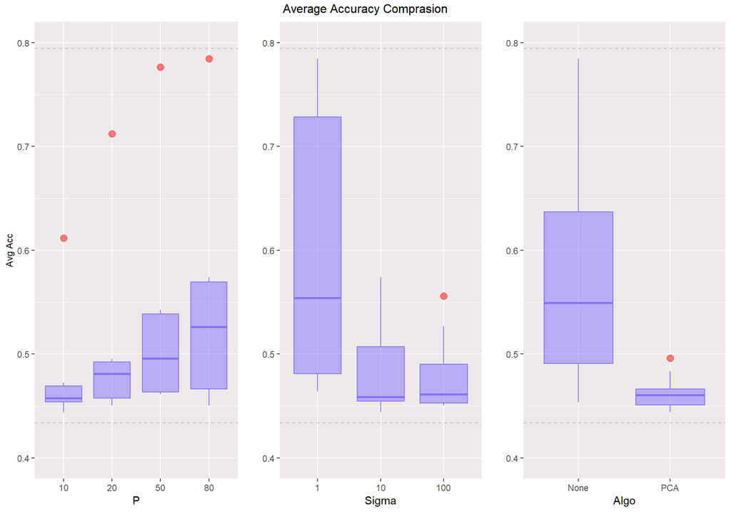

# Question 2

After choosing a random sample of 20 cities we generated 2 subsets of the original data (Demographic and Election)

## Election Data

First, we transformed the *Election Data* to percentages, i.e. computed the percentage voted for each faction per city. Then we built a Hierarchical tree using $Euclidean$ distance of the Election data

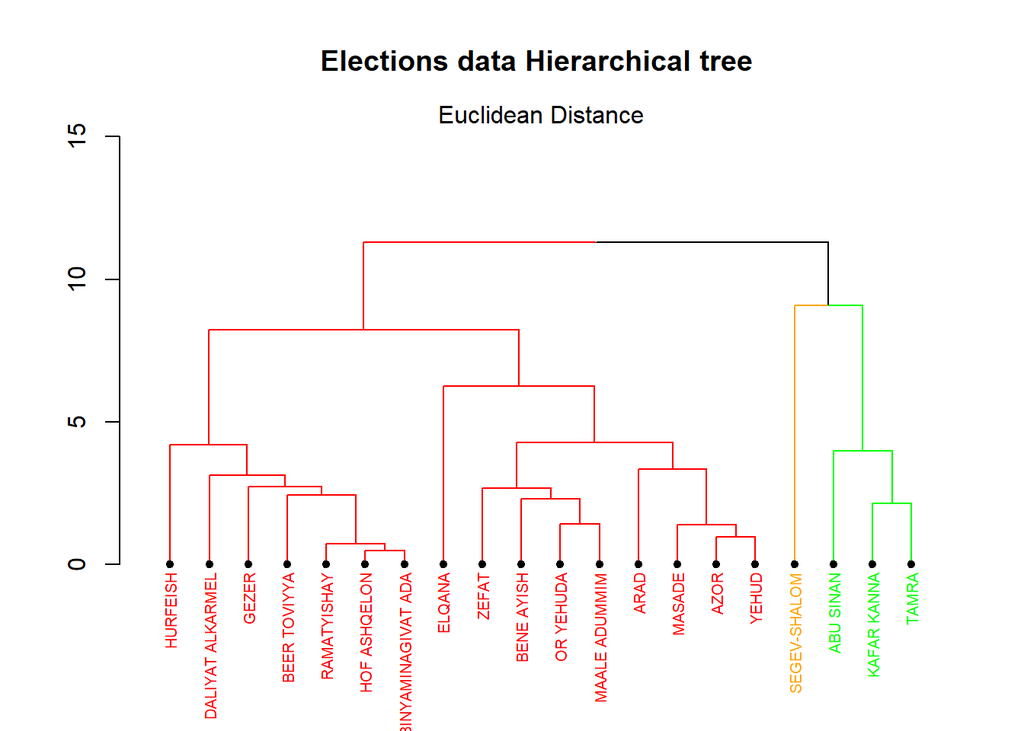

We choose not to include the political faction that were simmilar between different cities and focused at the statistical clustering,

## Demographic Data

First, we transformed the *Demographic Data* to $log$ (base $e$, Natural log), i.e. computed the $log$ value for each demographic variable. Then we built a Hierarchical tree using $Euclidean$ distance of the Demographic data

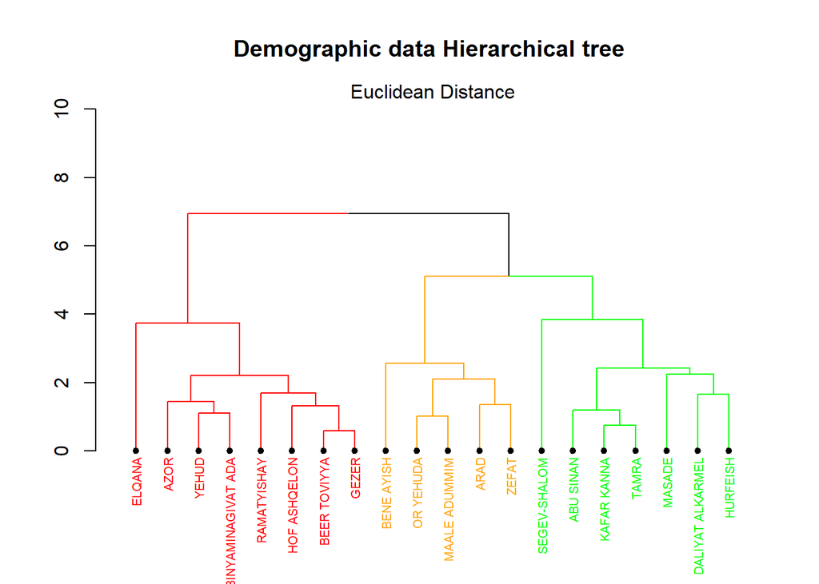

*Prima Facie* the clustering is a bit different than the *Election* data, i.e. *Arad* and *Azor* had similar election patterns but different Demograhpic structure!.

## Hierarchies Comparsion

First we want to give a graphical intution of the differences between the hierarchies of the *Demographic* and *Election* data.

We used the `tanglegram` function that plot the tree side by side and draws lines between the cities, horizontal lines imply that the city location didn’t change.

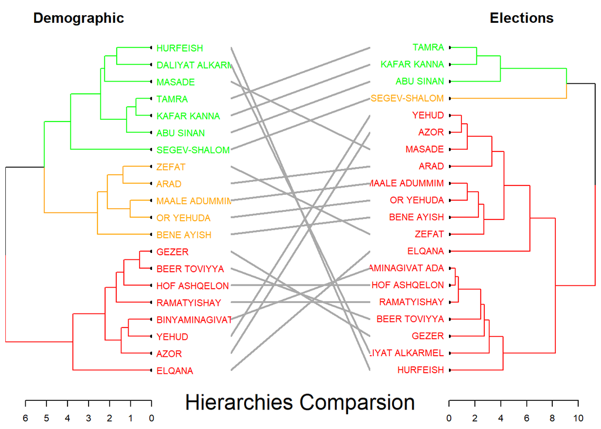

- To have a numerical comparsion between the trees we used *Baker’s Gamma Index* which measure similarity (accosiation ) between two Hierarchical trees.
- *Baker’s Gamma Index* is calculated by taking two items, and see what is the heighst possible level of k (number of cluster groups created when cutting the tree) for which the two item still belongs to the same tre
- *Baker’s Gamma Index* takes two cities and check what is the highest possible level of number of cluster groups created for which the two cities will still be assignd to the same tree. Then it comptue it for all cities pairs and calculate the Pearson correlation which imply that trees with *Baker’s Gamma Index* $\to \pm 1$ imply a strong positiveassociation between the trees and *Baker’s Gamma Index* $\to 0$ imply a weak one.
- We got a *Baker’s Gamma Index* equal to 0.20842 between the trees. which imply a relative weak positive association.

## Permutation Test

We did a permutation test for the calculation of the statistical significance of the *Baker’s Gamma Index*, i.e. we wanted to check the hypothesis:

$$H_0 = Demographic \quad and \quad Election \quad data \quad completly \quad unrelated$$

which of course imply a *Baker’s Gamma Index* equal to 0.

We checked the two-sided hypothesis, i.e. there isn’t *any* accosiation between the two data bases We premute the *Demographic* data labels 100 times and in each iteration we built a new tree and calcualted the *Baker’s Gamma Index*. After we ran 100 iteration we compared the empricial $P-Value$ using the formula:

$$P-Value := \frac{\sum{x_i}}{100}$$
While $x_i$ is *Baker’s Gamma Index* at iteration $i$ that is larger (ablsoute value) than the original *Baker’s Gamma Index* (not permutated)

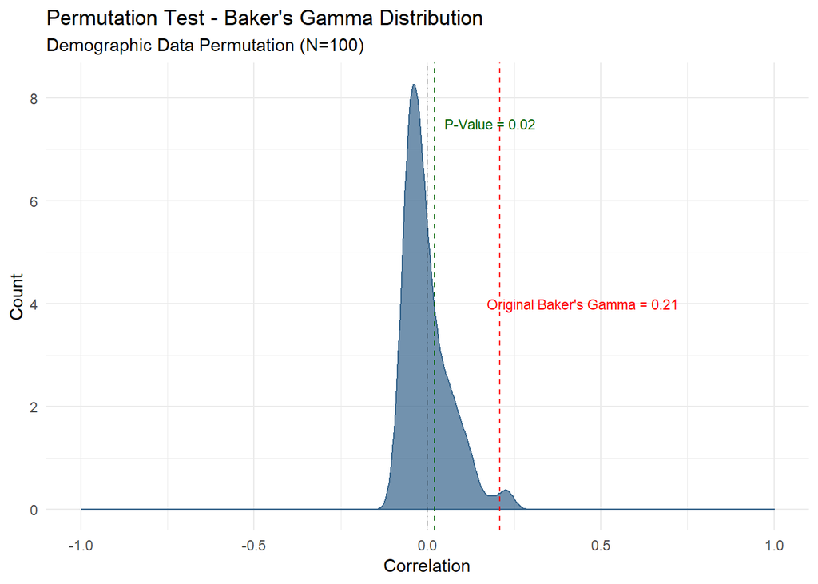

Remarks:

1. The Empirical $P-Value$ is 0.02, which imply that we can reject the Null-Hypothesis, i.e. the city label does effect the trees association.
2. Most of the *Baker’s Gamma Index* from the permutation are around 0, i.e. imply a very weak assoication between the permutated tress.
3. Even though the original *Baker’s Gamma Index* imply a weak association between the Demographic and Election data between cities, its still larger than a completly random one.